# Tiny Project: Exploratory Data Analysis of Car Fuel Efficiency

An Analysis of the Motor Trend Car Road Tests (mtcars) Dataset

Shreya Joshi

2026-09-22

# 1 Introduction

This project explores the **`mtcars`** dataset, which was extracted from the 1974 *Motor Trend* US magazine. It contains fuel consumption and 10 aspects of automobile design and performance for 32 automobiles (1973–74 models).

**Objective:** To understand which factors (engine size, weight, horsepower, number of cylinders, etc.) are most strongly associated with a car’s fuel efficiency, measured in miles per gallon (mpg).

The report follows a complete data analysis pipeline:

1. Importing the data
2. Cleaning and preprocessing
3. Statistical exploration
4. Visualization
5. Interpretation and conclusions

# 2 Loading Required Packages

We use `ggplot2` for visualization and `dplyr` for data manipulation. Both are widely used tidyverse packages for data analysis in R.

```r
# Install packages only if they are not already installed
packages <- c("ggplot2", "dplyr", "corrplot")
new_packages <- packages[!(packages %in% installed.packages()[, "Package"])]
if (length(new_packages) > 0) install.packages(new_packages)

library(ggplot2)   # for creating graphs and plots
library(dplyr)     # for data manipulation (filter, group_by, summarise, etc.)
library(corrplot)  # for correlation matrix visualization
```

**Code explanation:** We first check which of the required packages are already installed and only install the ones that are missing. This avoids reinstalling packages unnecessarily every time the report is knit. `library()` then loads each package into the current R session so its functions become available.

# 3 Data Importing

Although `mtcars` is a dataset built into R, we simulate a **real-world import workflow**: we first export it as a `.csv` file (as if it came from an external source, such as a database or survey export) and then re-import it using `read.csv()`, exactly as you would with any external dataset.

```r
# Step 1: Export the built-in mtcars dataset to a CSV file (simulating an
# external data source, e.g. downloaded from a database)
data(mtcars)
write.csv(mtcars, "mtcars_data.csv", row.names = TRUE)

# Step 2: Import the CSV file back into R, as we would with any raw dataset
car_data <- read.csv("mtcars_data.csv", row.names = 1, stringsAsFactors = FALSE)

# Preview the imported data
head(car_data)
```

|  | mpg | cyl | disp | hp | drat | wt | qsec | vs | am | gear | carb |
| --- | --- | --- | --- | --- | --- | --- | --- | --- | --- | --- | --- |
| Mazda RX4 | 21.0 | 6 | 160 | 110 | 3.90 | 2.620 | 16.46 | 0 | 1 | 4 | 4 |
| Mazda RX4 Wag | 21.0 | 6 | 160 | 110 | 3.90 | 2.875 | 17.02 | 0 | 1 | 4 | 4 |
| Datsun 710 | 22.8 | 4 | 108 | 93 | 3.85 | 2.320 | 18.61 | 1 | 1 | 4 | 1 |
| Hornet 4 Drive | 21.4 | 6 | 258 | 110 | 3.08 | 3.215 | 19.44 | 1 | 0 | 3 | 1 |
| Hornet Sportabout | 18.7 | 8 | 360 | 175 | 3.15 | 3.440 | 17.02 | 0 | 0 | 3 | 2 |
| Valiant | 18.1 | 6 | 225 | 105 | 2.76 | 3.460 | 20.22 | 1 | 0 | 3 | 1 |

**Code explanation:**

- `write.csv()` writes the data frame to a `.csv` file. `row.names = TRUE` keeps the car names as the first column.
- `read.csv()` reads the CSV back into R as a data frame. `row.names = 1` tells R to treat the first column (car names) as row labels rather than a regular data column.
- `head()` displays the first six rows so we can visually confirm the import worked correctly.

# 4 Data Preprocessing and Cleaning

## 4.1 Inspecting the Structure

```r
str(car_data)
```

```
## 'data.frame':    32 obs. of  11 variables:
##  $ mpg : num  21 21 22.8 21.4 18.7 18.1 14.3 24.4 22.8 19.2 ...
##  $ cyl : int  6 6 4 6 8 6 8 4 4 6 ...
##  $ disp: num  160 160 108 258 360 ...
##  $ hp  : int  110 110 93 110 175 105 245 62 95 123 ...
##  $ drat: num  3.9 3.9 3.85 3.08 3.15 2.76 3.21 3.69 3.92 3.92 ...
##  $ wt  : num  2.62 2.88 2.32 3.21 3.44 ...
##  $ qsec: num  16.5 17 18.6 19.4 17 ...
##  $ vs  : int  0 0 1 1 0 1 0 1 1 1 ...
##  $ am  : int  1 1 1 0 0 0 0 0 0 0 ...
##  $ gear: int  4 4 4 3 3 3 3 4 4 4 ...
##  $ carb: int  4 4 1 1 2 1 4 2 2 4 ...
```

```r
dim(car_data)
```

```
## [1] 32 11
```

**Interpretation:** The dataset has 32 observations (cars) and 11 variables, all currently stored as numeric. Several of these (e.g. `cyl`, `vs`, `am`, `gear`, `carb`) are actually **categorical** variables encoded as numbers, so they need to be converted to factors for accurate analysis.

## 4.2 Checking for Missing Values

```r
colSums(is.na(car_data))
```

```
##  mpg  cyl disp   hp drat   wt qsec   vs   am gear carb
##    0    0    0    0    0    0    0    0    0    0    0
```

**Interpretation:** There are no missing values in any column, so no imputation or row removal is necessary. This is common with this dataset but is always an essential check before analysis.

## 4.3 Converting Variables to Proper Types

```r
car_data_clean <- car_data %>%
  mutate(
    cyl  = factor(cyl, levels = c(4, 6, 8), labels = c("4-cyl", "6-cyl", "8-cyl")),
    vs   = factor(vs, levels = c(0, 1), labels = c("V-shaped", "Straight")),
    am   = factor(am, levels = c(0, 1), labels = c("Automatic", "Manual")),
    gear = factor(gear),
    carb = factor(carb)
  )

# Add car names as an explicit column for easier plotting later
car_data_clean$car_name <- rownames(car_data_clean)

head(car_data_clean)
```

|  | mpg | cyl | disp | hp | drat | wt | qsec | vs | am | gear | carb | car_name |
| --- | --- | --- | --- | --- | --- | --- | --- | --- | --- | --- | --- | --- |
| Mazda RX4 | 21.0 | 6-cyl | 160 | 110 | 3.90 | 2.620 | 16.46 | V-shaped | Manual | 4 | 4 | Mazda RX4 |
| Mazda RX4 Wag | 21.0 | 6-cyl | 160 | 110 | 3.90 | 2.875 | 17.02 | V-shaped | Manual | 4 | 4 | Mazda RX4 Wag |
| Datsun 710 | 22.8 | 4-cyl | 108 | 93 | 3.85 | 2.320 | 18.61 | Straight | Manual | 4 | 1 | Datsun 710 |
| Hornet 4 Drive | 21.4 | 6-cyl | 258 | 110 | 3.08 | 3.215 | 19.44 | Straight | Automatic | 3 | 1 | Hornet 4 Drive |
| Hornet Sportabout | 18.7 | 8-cyl | 360 | 175 | 3.15 | 3.440 | 17.02 | V-shaped | Automatic | 3 | 2 | Hornet Sportabout |
| Valiant | 18.1 | 6-cyl | 225 | 105 | 2.76 | 3.460 | 20.22 | Straight | Automatic | 3 | 1 | Valiant |

**Code explanation:**

- `mutate()` (from `dplyr`) creates or transforms columns.
- `factor()` converts numeric codes into labeled categorical variables — for example, `cyl` becomes “4-cyl”, “6-cyl”, or “8-cyl” instead of just 4, 6, 8. This makes plots and summaries far easier to interpret.
- We also extract the row names (car models) into their own column, since `ggplot2` works more easily with data stored in columns than in row names.

# 5 Data Analysis and Statistical Exploration

## 5.1 Summary Statistics

```r
summary(car_data_clean[, c("mpg", "hp", "wt", "disp", "qsec")])
```

```
##       mpg              hp              wt             disp
##  Min.   :10.40   Min.   : 52.0   Min.   :1.513   Min.   : 71.1
##  1st Qu.:15.43   1st Qu.: 96.5   1st Qu.:2.581   1st Qu.:120.8
##  Median :19.20   Median :123.0   Median :3.325   Median :196.3
##  Mean   :20.09   Mean   :146.7   Mean   :3.217   Mean   :230.7
##  3rd Qu.:22.80   3rd Qu.:180.0   3rd Qu.:3.610   3rd Qu.:326.0
##  Max.   :33.90   Max.   :335.0   Max.   :5.424   Max.   :472.0
##       qsec
##  Min.   :14.50
##  1st Qu.:16.89
##  Median :17.71
##  Mean   :17.85
##  3rd Qu.:18.90
##  Max.   :22.90
```

**Interpretation:** The average fuel efficiency across all cars is around 20 mpg, ranging from about 10.4 to 33.9 mpg. Horsepower (`hp`) and weight (`wt`) both show wide variation, hinting that they may explain differences in mpg.

## 5.2 Average MPG by Number of Cylinders

```r
mpg_by_cyl <- car_data_clean %>%
  group_by(cyl) %>%
  summarise(
    avg_mpg = mean(mpg),
    avg_hp  = mean(hp),
    count   = n()
  )

mpg_by_cyl
```

| cyl | avg_mpg | avg_hp | count |
| --- | --- | --- | --- |
| 4-cyl | 26.66364 | 82.63636 | 11 |
| 6-cyl | 19.74286 | 122.28571 | 7 |
| 8-cyl | 15.10000 | 209.21429 | 14 |

**Interpretation:** Cars with fewer cylinders (4-cyl) have noticeably higher average mpg than those with 8 cylinders, while horsepower shows the opposite pattern — more cylinders generally means more power but lower fuel economy.

## 5.3 Correlation Analysis

```r
numeric_vars <- car_data_clean %>% select(mpg, hp, wt, disp, qsec, drat)
cor_matrix <- cor(numeric_vars)
round(cor_matrix, 2)
```

```
##        mpg    hp    wt  disp  qsec  drat
## mpg   1.00 -0.78 -0.87 -0.85  0.42  0.68
## hp   -0.78  1.00  0.66  0.79 -0.71 -0.45
## wt   -0.87  0.66  1.00  0.89 -0.17 -0.71
## disp -0.85  0.79  0.89  1.00 -0.43 -0.71
## qsec  0.42 -0.71 -0.17 -0.43  1.00  0.09
## drat  0.68 -0.45 -0.71 -0.71  0.09  1.00
```

# 6 Graphs and Plots

## 6.1 Distribution of MPG

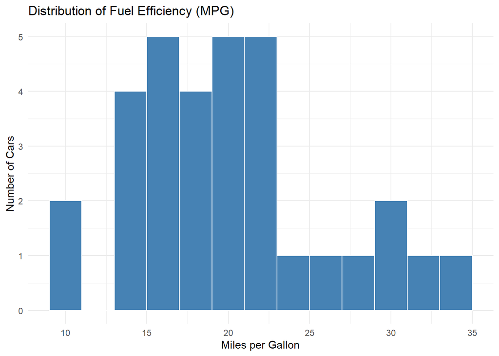

```r
ggplot(car_data_clean, aes(x = mpg)) +
  geom_histogram(binwidth = 2, fill = "steelblue", color = "white") +
  labs(title = "Distribution of Fuel Efficiency (MPG)",
       x = "Miles per Gallon", y = "Number of Cars") +
  theme_minimal()
```

**Interpretation:** Most cars cluster between 15 and 22 mpg, with a smaller number of highly efficient cars above 25 mpg.

## 6.2 MPG vs Weight, Colored by Cylinder Count

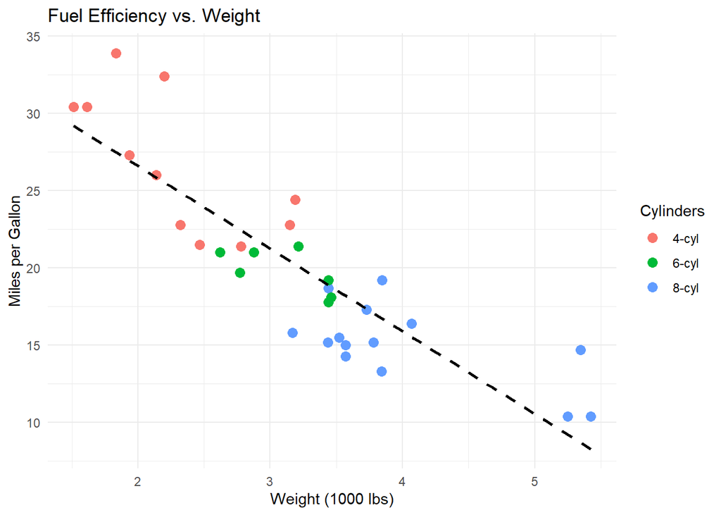

```r
ggplot(car_data_clean, aes(x = wt, y = mpg, color = cyl)) +
  geom_point(size = 3) +
  geom_smooth(method = "lm", se = FALSE, color = "black", linetype = "dashed") +
  labs(title = "Fuel Efficiency vs. Weight",
       x = "Weight (1000 lbs)", y = "Miles per Gallon", color = "Cylinders") +
  theme_minimal()
```

**Interpretation:** There is a clear downward trend — as weight increases, mpg decreases. Cars with 8 cylinders also tend to be heavier and cluster in the lower-mpg region, reinforcing the correlation seen earlier.

## 6.3 MPG by Cylinder Count (Boxplot)

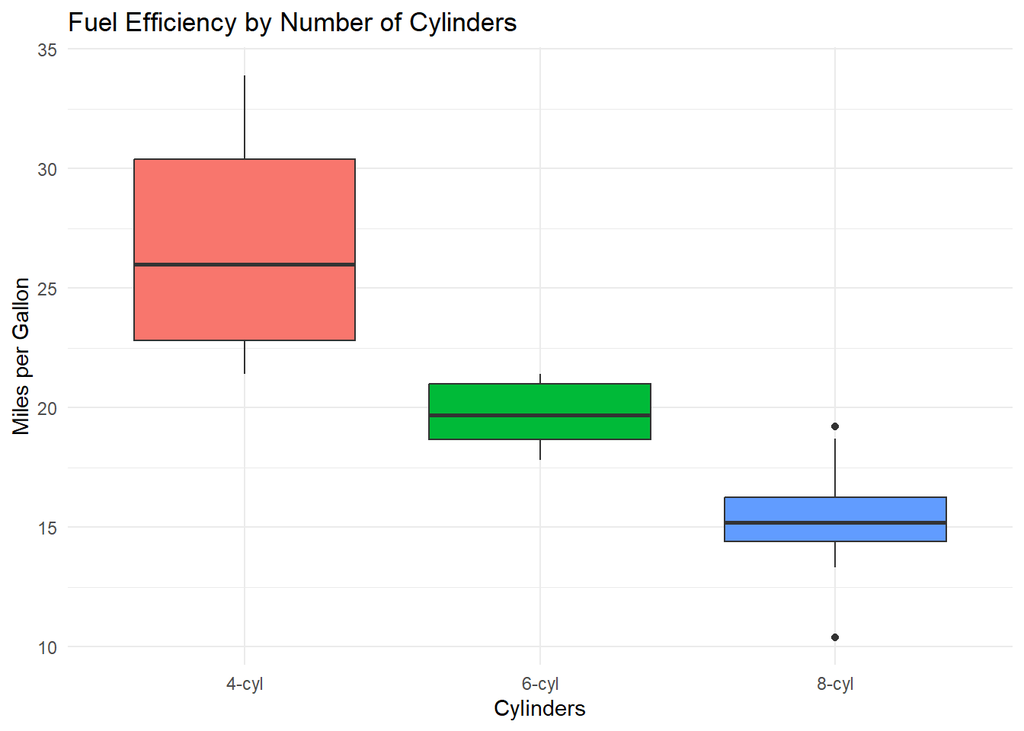

```r
ggplot(car_data_clean, aes(x = cyl, y = mpg, fill = cyl)) +
  geom_boxplot() +
  labs(title = "Fuel Efficiency by Number of Cylinders",
       x = "Cylinders", y = "Miles per Gallon") +
  theme_minimal() +
  theme(legend.position = "none")
```

**Interpretation:** The boxplot confirms that median mpg drops steadily as cylinder count increases, with relatively little overlap between the 4-cylinder and 8-cylinder groups.

## 6.4 Correlation Heatmap

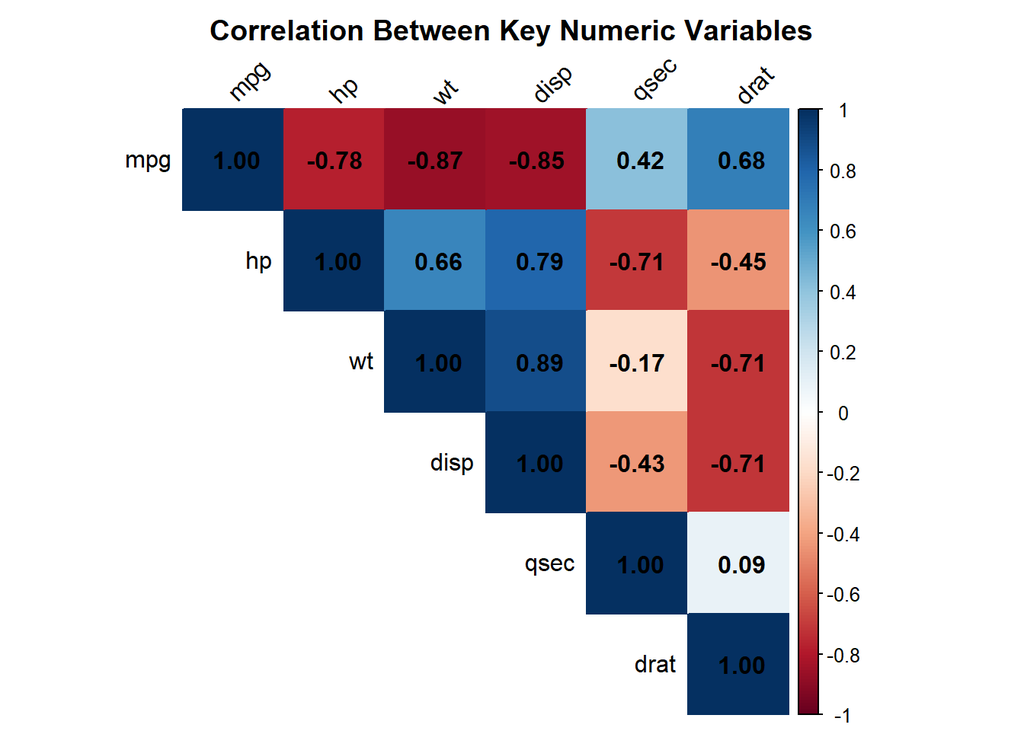

```r
corrplot(cor_matrix, method = "color", type = "upper",
         addCoef.col = "black", tl.col = "black", tl.srt = 45,
         title = "Correlation Between Key Numeric Variables",
         mar = c(0, 0, 2, 0))
```

**Interpretation:** The heatmap visually confirms strong negative correlations between `mpg` and both `wt` and `disp`, and a strong positive correlation between `wt` and `disp` themselves (heavier cars tend to have larger engines).

# 7 Findings and Conclusion

Based on the exploratory analysis of the `mtcars` dataset:

- **Weight is the strongest predictor of poor fuel efficiency** — heavier cars consistently get fewer miles per gallon.
- **Cylinder count matters**: 4-cylinder cars average substantially higher mpg than 6- or 8-cylinder cars, largely because they are lighter and less powerful.
- **Horsepower and displacement** are both negatively associated with mpg, though weight remains the dominant factor.
- Cars optimized for fuel economy in this dataset tend to be lighter, smaller-engine, 4-cylinder vehicles.

**Conclusion:** This project demonstrates a complete R data analysis workflow — from importing raw data, cleaning and transforming variables, exploring statistical relationships, to visualizing and interpreting results. The analysis confirms that vehicle weight and engine size are the primary determinants of fuel efficiency in this 1974 dataset, a pattern that still holds broadly true for vehicles today.

[session information not shown]

*(Including `sessionInfo()` is good practice — it records the R version and package versions used, which helps with reproducibility.)*